# Data Review - Fenbid Forecasting Report

**Nielsen Advanced Analytic Consulting**

2020-06-13

## Content

**1 Data summary**

**2 Base Factors**

– 2.1 Weighted Distribution

– 2.2 DU Price

– 2.3 Category Value

**3 ATL Factors**

– 3.1 TV

– 3.2 OTV

– 3.3 Digital

– 3.4 SEM

**4 BTL Factors**

– 4.1 Brand Reminder

– 4.2 POSM

### 1.Data summary

|  | 2017 | 2018 | 2019 | 2020 |
| --- | --- | --- | --- | --- |
| Weighted.Distribution | 80.8 | 81.0 | 81.9 | 79.3 |
| DU.Price | 11.1 | 11.2 | 12.6 | 13.4 |
| Category.Value(M) | 1076.5 | 1132.1 | 1314.6 | 1239.0 |
| TV.Spending(M) | 42424.4 | 54651.6 | 42869.6 | 37327.2 |
| OTV.Spending(M) | 7489.8 | 15174.2 | 30832.1 | 24818.2 |
| Digital.Spending(M) | 4464.8 | 15584.2 | 20042.5 | 32065.0 |
| SEM.Spending(M) | 3304.8 | 4208.8 | 7951.8 | 11233.5 |
| Brand.Reminder.Spending(M) | 2161.8 | 1103.3 | 3854.3 | 0.5 |
| POSM.Spending(M) | 2591.6 | 682.1 | 3942.8 | 1.1 |

### 2. Volumetric Data Review

#### 2.1 Weighted Distribution

Weighted Distribution for Fenbid is expected at about 79.26 in CY2020, which is 3.26% lower than the value in 2019.

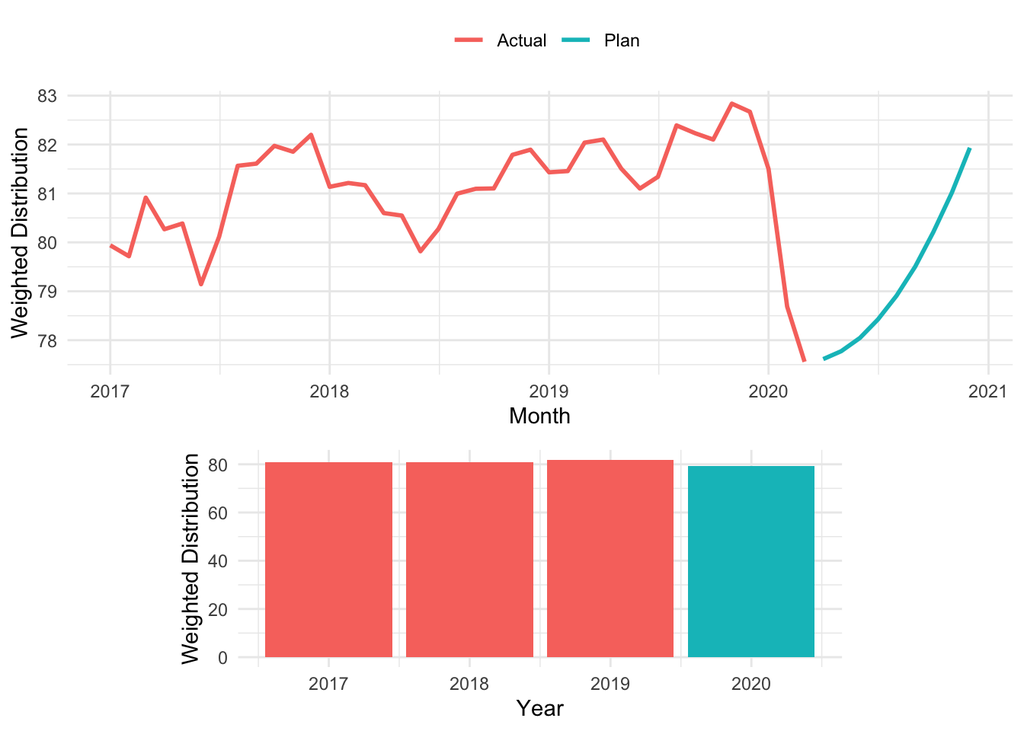

|  | 1 | 2 | 3 | 4 | 5 | 6 | 7 | 8 | 9 | 10 | 11 | 12 |
| --- | --- | --- | --- | --- | --- | --- | --- | --- | --- | --- | --- | --- |
| 2019 | 81.43 | 81.46 | 82.04 | 82.10 | 81.51 | 81.10 | 81.34 | 82.39 | 82.23 | 82.10 | 82.84 | 82.67 |
| 2020 | 81.50 | 78.69 | 77.56 | 77.61 | 77.78 | 78.05 | 78.42 | 78.91 | 79.50 | 80.21 | 81.02 | 81.93 |

#### 2.2 DU Price

DU Price for Fenbid is expected at about 1.11 in CY2020, which is 5.59% higher than the value in 2019.

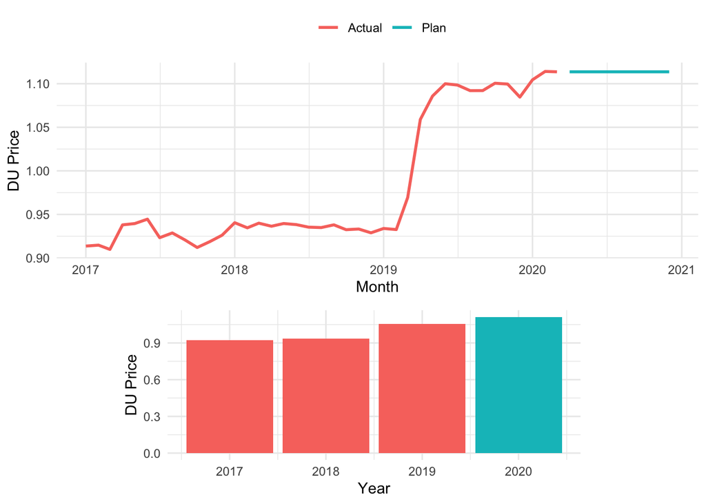

|  | 1 | 2 | 3 | 4 | 5 | 6 | 7 | 8 | 9 | 10 | 11 | 12 |
| --- | --- | --- | --- | --- | --- | --- | --- | --- | --- | --- | --- | --- |
| 2019 | 0.93 | 0.93 | 0.97 | 1.06 | 1.09 | 1.10 | 1.10 | 1.09 | 1.09 | 1.10 | 1.10 | 1.08 |
| 2020 | 1.10 | 1.11 | 1.11 | 1.11 | 1.11 | 1.11 | 1.11 | 1.11 | 1.11 | 1.11 | 1.11 | 1.11 |

#### 2.3 Category Value

Category Value(M) for Fenbid is expected at about 1,239 in CY2020, which is 5.75% lower than the value in 2019.

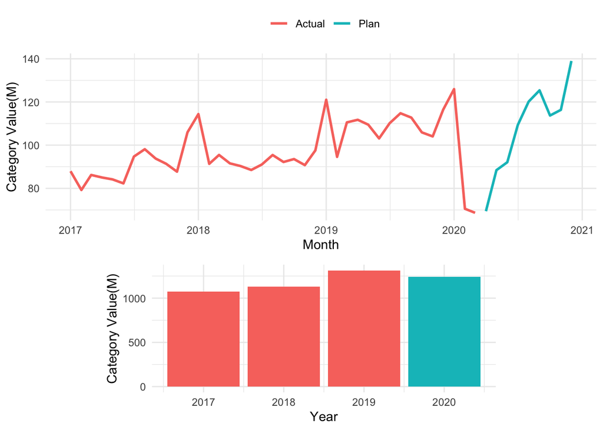

|  | 1 | 2 | 3 | 4 | 5 | 6 | 7 | 8 | 9 | 10 | 11 | 12 |
| --- | --- | --- | --- | --- | --- | --- | --- | --- | --- | --- | --- | --- |
| 2019 | 121 | 94.58 | 110.55 | 111.75 | 109.49 | 103.11 | 110.2 | 114.8 | 112.8 | 105.9 | 104.0 | 116.5 |
| 2020 | 126 | 70.54 | 68.67 | 69.42 | 88.42 | 92.09 | 109.3 | 120.2 | 125.4 | 113.7 | 116.3 | 139.0 |

### 3 ATL Data Review

#### 3.1 TV Spending

TV Spending(M) for Fenbid is expected at about 37,327 in CY2020, which is 12.93% lower than the value in 2019.

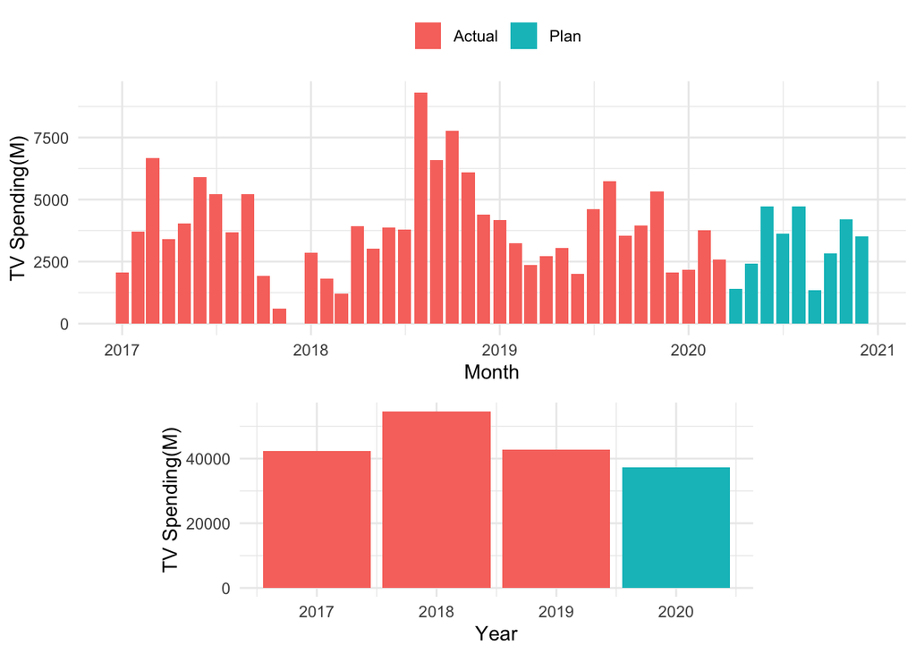

|  | 1 | 2 | 3 | 4 | 5 | 6 | 7 | 8 | 9 | 10 | 11 | 12 |
| --- | --- | --- | --- | --- | --- | --- | --- | --- | --- | --- | --- | --- |
| 2019 | 4176 | 3249 | 2372 | 2721 | 3047 | 2018 | 4623 | 5751 | 3554 | 3961 | 5331 | 2067 |
| 2020 | 2179 | 3757 | 2585 | 1415 | 2405 | 4730 | 3635 | 4718 | 1351 | 2842 | 4193 | 3517 |

#### 3.2 OTV Spending

OTV Spending(M) for Fenbid is expected at about 24,818 in CY2020, which is 19.51% lower than the value in 2019.

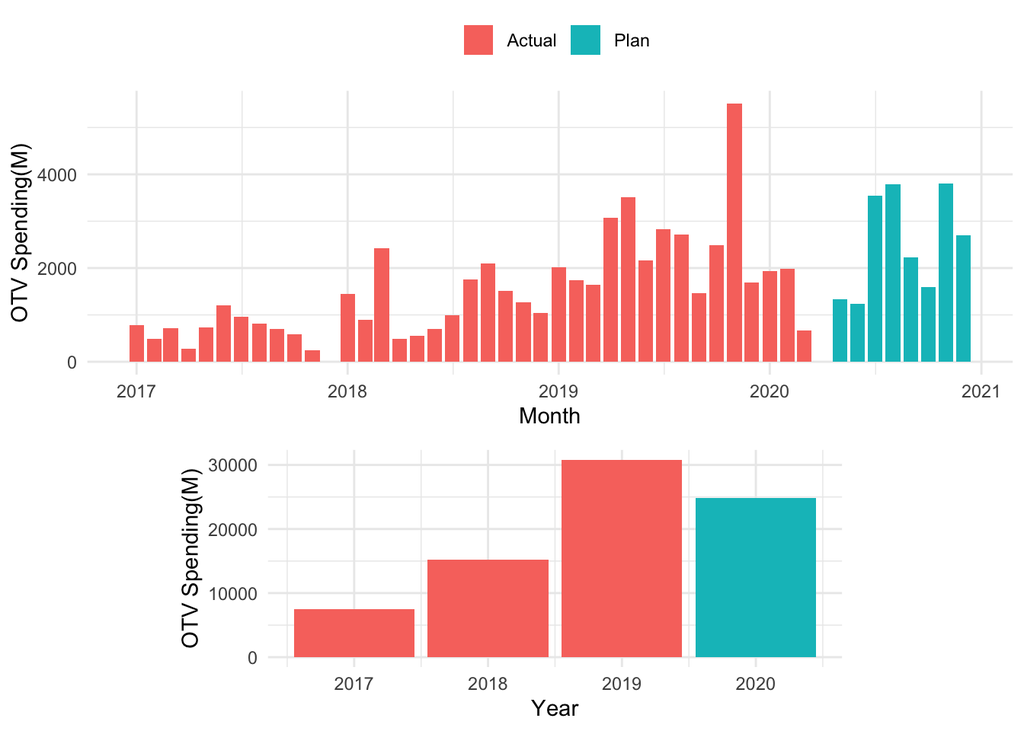

|  | 1 | 2 | 3 | 4 | 5 | 6 | 7 | 8 | 9 | 10 | 11 | 12 |
| --- | --- | --- | --- | --- | --- | --- | --- | --- | --- | --- | --- | --- |
| 2019 | 2018 | 1738 | 1635 | 3079 | 3512 | 2163 | 2821 | 2714 | 1457 | 2492 | 5509 | 1694 |
| 2020 | 1928 | 1983 | 675 | 0 | 1338 | 1244 | 3543 | 3782 | 2222 | 1590 | 3812 | 2701 |

#### 3.3 Digital Spending

Digital Spending(M) for Fenbid is expected at about 32,065 in CY2020, which is 59.98% higher than the value in 2019.

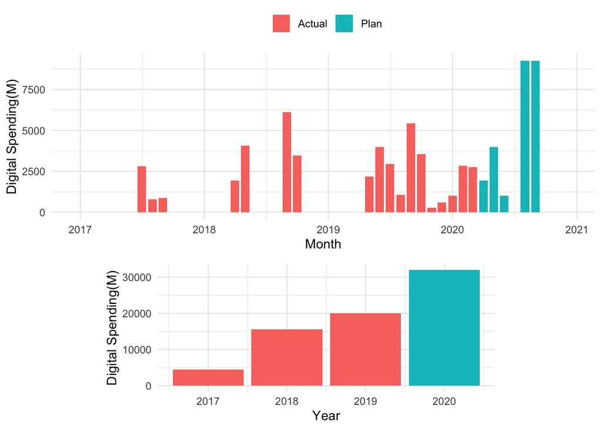

|  | 1 | 2 | 3 | 4 | 5 | 6 | 7 | 8 | 9 | 10 | 11 | 12 |
| --- | --- | --- | --- | --- | --- | --- | --- | --- | --- | --- | --- | --- |
| 2019 | 0 | 0 | 0 | 0 | 2178 | 3995 | 2952 | 1062 | 5421 | 3559 | 275 | 600 |
| 2020 | 1023 | 2851 | 2755 | 1933 | 4000 | 1000 | 0 | 9252 | 9252 | 0 | 0 | 0 |

#### 3.4 SEM Spending

SEM Spending(M) for Fenbid is expected at about 11,234 in CY2020, which is 41.27% higher than the value in 2019. `

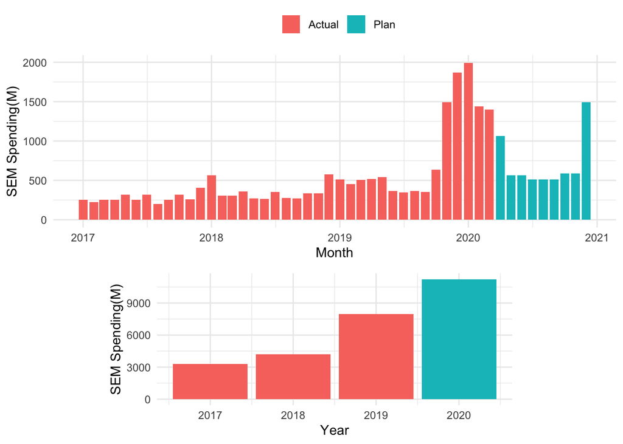

|  | 1 | 2 | 3 | 4 | 5 | 6 | 7 | 8 | 9 | 10 | 11 | 12 |
| --- | --- | --- | --- | --- | --- | --- | --- | --- | --- | --- | --- | --- |
| 2019 | 513 | 451.7 | 507.4 | 519.3 | 538.6 | 363.5 | 345.8 | 363.4 | 352.5 | 637.1 | 1492.9 | 1867 |
| 2020 | 1992 | 1442.3 | 1397.7 | 1064.3 | 564.3 | 564.3 | 513.0 | 513.0 | 513.0 | 589.9 | 589.9 | 1490 |

### 4 BTL Data Review

#### 4.1 Brand Reminder Spending

Brand Reminder Spending(M) for Fenbid is expected at about 0 in CY2020, which is 99.99% lower than the value in 2019.

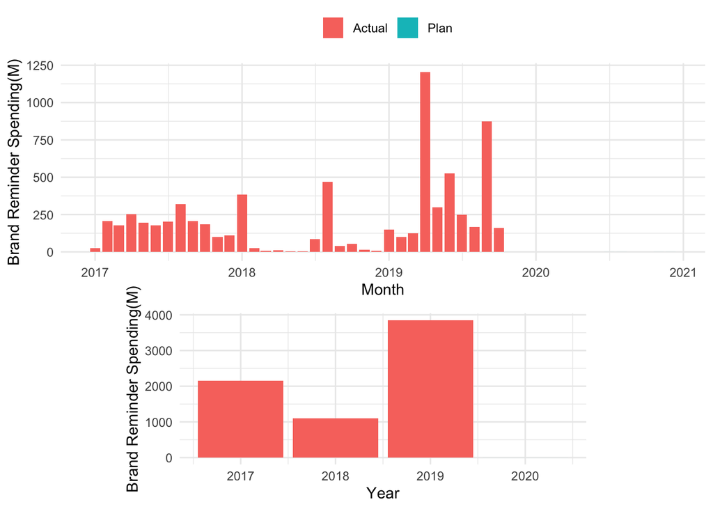

|  | 1 | 2 | 3 | 4 | 5 | 6 | 7 | 8 | 9 | 10 | 11 | 12 |
| --- | --- | --- | --- | --- | --- | --- | --- | --- | --- | --- | --- | --- |
| 2019 | 148 | 99.44 | 126.3 | 1204 | 297.5 | 525.6 | 250.49 | 168.07 | 874.2 | 160.9 | 0.00 | 0.00 |
| 2020 | 0 | 0.00 | 0.0 | 0 | 0.0 | 0.0 | 0.12 | 0.12 | 0.0 | 0.0 | 0.12 | 0.12 |

#### 4.2 POSM Spending

POSM Spending(M) for Fenbid is expected at about 1 in CY2020, which is 99.97% lower than the value in 2019.

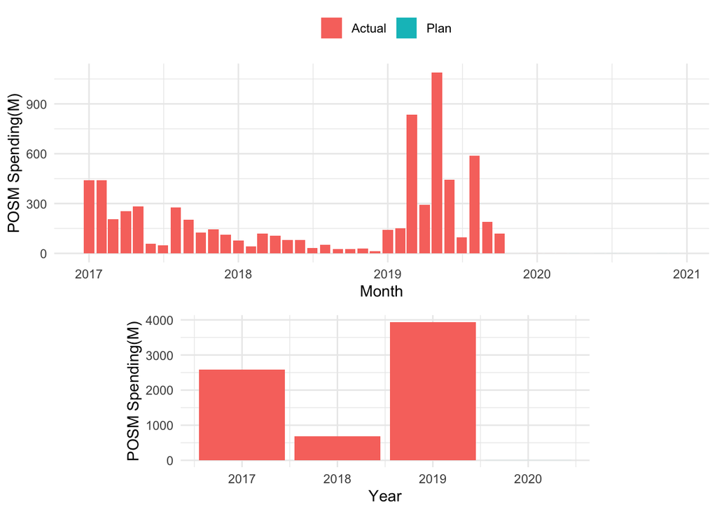

[output not shown]